# **Predicting Population Trends Using Deep Learning- Final Project**

Data Source: https://www.kaggle.com/datasets/census/population-time-series-data/data

Git: https://github.com/AnushaK7018/introduction-to-deep-learning-final

## **Objective:**

The primary objective of this project is to develop a deep learning model capable of accurately predicting population trends based on historical time-series data. The project aims to leverage advanced neural network architectures, such as LSTM, GRU, and Bidirectional LSTM, to identify the best-performing model that can effectively capture temporal dependencies in the data. The goal is to create a model that can be used for forecasting future population values, which could be valuable for planning, resource allocation, and decision-making processes.

## **Goal:**

Develop and compare multiple deep learning models, specifically focusing on LSTM, GRU, and Bidirectional LSTM architectures. Conduct thorough hyperparameter tuning to optimize model performance. Evaluate the models using key metrics such as Mean Absolute Error (MAE), Root Mean Squared Error (RMSE), and R-squared (R²) to identify the best model.

## **Data Description:**

We have two datasets:

**POP.csv:**

Rows: 816

Columns: 4 (realtime_start, value, date, realtime_end)

Data Types: realtime_start, date, realtime_end are objects (likely strings representing dates), and value is a float.

Description: This dataset includes 816 entries, with a value that represent a population metric data recorded monthly from January 1952.

**POPH.csv:**

Rows: 100

Columns: 4 (realtime_start, value, date, realtime_end)

Data Types: realtime_start, date, realtime_end are objects, and value is an integer.

Description: This dataset contains 100 entries, with a value field that represent a population metric, starting from January 1900.

## **Modeling Approach:**

LSTM (Long Short-Term Memory) Model: LSTM networks are well-suited for time-series prediction because they can capture long-term dependencies and patterns in sequential data.

GRU (Gated Recurrent Unit) Model: GRU is a simpler alternative to LSTM, designed to achieve similar performance with fewer computational resources.

Bidirectional LSTM Model: This model processes the input data in both forward and backward directions, potentially capturing more context from the time series.

```python
import pandas as pd
from google.colab import drive
drive.mount('/content/drive')
```

```python
import pandas as pd
import matplotlib.pyplot as plt
import seaborn as sns

# Load the datasets
poph_df = pd.read_csv('/content/drive/My Drive/Population Time Series Data/POPH.csv')
pop_df = pd.read_csv('/content/drive/My Drive/Population Time Series Data/POP.csv')
```

## **Exploratory Data Analysis (EDA) — Inspect, Visualize, and Clean the Data**

In this step, we'll conduct the following:

- Inspect the data for missing values, anomalies, and basic statistics.
- Visualize the data using histograms and line plots to understand trends and distributions.
- Plan of analysis based on the findings.

```python
# Display the first few rows of each dataset
print("First few rows of POP.csv:")
print(pop_df.head())

print("\nFirst few rows of POPH.csv:")
print(poph_df.head())

# Display basic information about the datasets
print("\nPOP.csv Info:")
print(pop_df.info())

print("\nPOPH.csv Info:")
print(poph_df.info())

# Display summary statistics
print("\nPOP.csv Summary Statistics:")
print(pop_df.describe())

print("\nPOPH.csv Summary Statistics:")
print(poph_df.describe())
```

```
First few rows of POP.csv:
  realtime_start     value        date realtime_end
0     2019-12-06  156309.0  1952-01-01   2019-12-06
1     2019-12-06  156527.0  1952-02-01   2019-12-06
2     2019-12-06  156731.0  1952-03-01   2019-12-06
3     2019-12-06  156943.0  1952-04-01   2019-12-06
4     2019-12-06  157140.0  1952-05-01   2019-12-06

First few rows of POPH.csv:
  realtime_start     value        date realtime_end
0     2019-12-06  76094000  1900-01-01   2019-12-06
1     2019-12-06  77584000  1901-01-01   2019-12-06
2     2019-12-06  79163000  1902-01-01   2019-12-06
3     2019-12-06  80632000  1903-01-01   2019-12-06
4     2019-12-06  82166000  1904-01-01   2019-12-06

POP.csv Info:
<class 'pandas.core.frame.DataFrame'>
RangeIndex: 816 entries, 0 to 815
Data columns (total 4 columns):
 #   Column          Non-Null Count  Dtype
---  ------          --------------  -----
 0   realtime_start  816 non-null    object
 1   value           816 non-null    float64
 2   date            816 non-null    object
 3   realtime_end    816 non-null    object
dtypes: float64(1), object(3)
memory usage: 25.6+ KB
None

POPH.csv Info:
<class 'pandas.core.frame.DataFrame'>
RangeIndex: 100 entries, 0 to 99
Data columns (total 4 columns):
 #   Column          Non-Null Count  Dtype
---  ------          --------------  -----
 0   realtime_start  100 non-null    object
 1   value           100 non-null    int64
 2   date            100 non-null    object
 3   realtime_end    100 non-null    object
```

[output cut: 10 more lines]

```
25%    201725.250000
50%    239557.500000
75%    289364.250000
max    330309.946000

POPH.csv Summary Statistics:
              value
count  1.000000e+02
mean   1.633956e+08
std    5.836305e+07
min    7.609400e+07
25%    1.153990e+08
50%    1.507298e+08
75%    2.143837e+08
max    2.726908e+08
```

```
Missing values in POP.csv:
realtime_start    0
value             0
date              0
realtime_end      0
dtype: int64

Missing values in POPH.csv:
realtime_start    0
value             0
date              0
realtime_end      0
dtype: int64
```

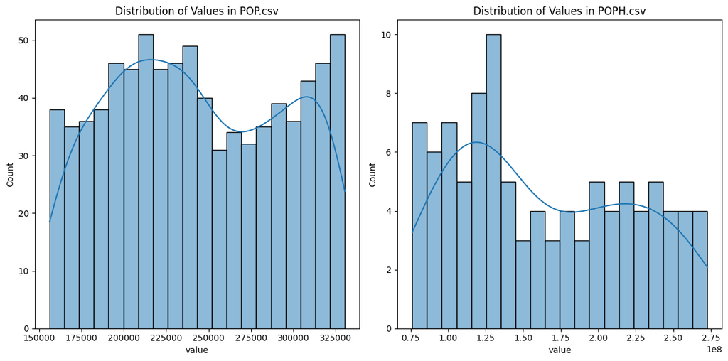

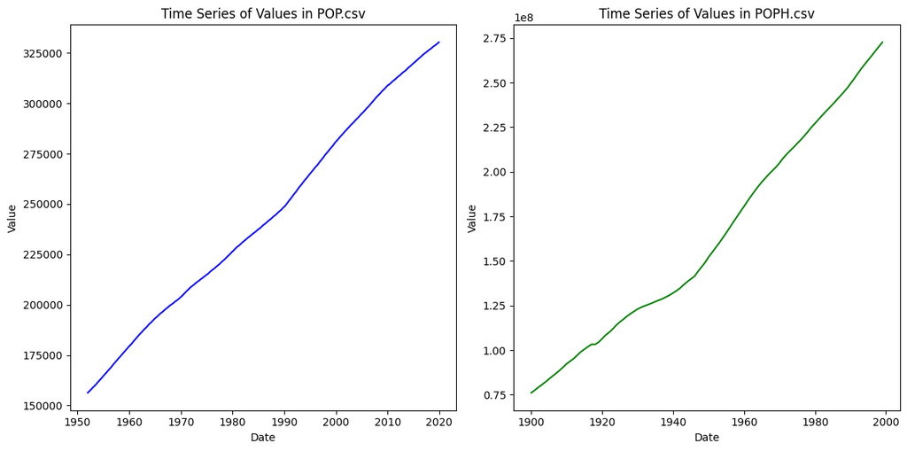

```python
import matplotlib.pyplot as plt
import seaborn as sns

# Convert date columns to datetime format
pop_df['date'] = pd.to_datetime(pop_df['date'])
poph_df['date'] = pd.to_datetime(poph_df['date'])

# Check for missing values
print("\nMissing values in POP.csv:")
print(pop_df.isnull().sum())

print("\nMissing values in POPH.csv:")
print(poph_df.isnull().sum())

# Plot histograms for the 'value' columns
plt.figure(figsize=(12, 6))

plt.subplot(1, 2, 1)
sns.histplot(pop_df['value'], bins=20, kde=True)
plt.title('Distribution of Values in POP.csv')

plt.subplot(1, 2, 2)
sns.histplot(poph_df['value'], bins=20, kde=True)
plt.title('Distribution of Values in POPH.csv')

plt.tight_layout()
plt.show()

# Plot time series of the 'value' columns
plt.figure(figsize=(12, 6))

plt.subplot(1, 2, 1)
plt.plot(pop_df['date'], pop_df['value'], color='blue')
plt.title('Time Series of Values in POP.csv')
plt.xlabel('Date')
plt.ylabel('Value')

plt.subplot(1, 2, 2)
plt.plot(poph_df['date'], poph_df['value'], color='green')
plt.title('Time Series of Values in POPH.csv')
plt.xlabel('Date')
plt.ylabel('Value')

plt.tight_layout()
plt.show()
```

### **Analysis of Visualizations and Data Insights:**

**Histograms of Values:**

The distribution in POPH.csv is more varied, with noticeable peaks, particularly around the 125,000,000 mark. This suggests different population growth patterns over time.

**Time Series Plots:**

Both datasets show a clear upward trend over time, indicating consistent growth in the value metric (population data). The POP.csv dataset shows this trend from the 1950s onward, while POPH.csv covers an earlier period from 1900 to 2000.

**Missing Values:**

There are no missing values in either dataset, so no data imputation or removal is necessary.

### **Plan of Analysis:**

Given the nature of the data (population over time), we can consider the following approaches:

**Modeling Strategy:**

*Time-Series Forecasting:* Given the trend observed in both datasets, a forecasting model like an LSTM or GRU could be appropriate for predicting future values based on historical data.

*Regression or Classification:* If there is a specific event or threshold we are interested in (e.g., when the population will reach a certain level), a regression model might also be appropriate.

*Feature Engineering:* We may consider creating additional features, such as year, month, or other time-related features, to capture seasonality or other temporal patterns. Scaling the value column might be necessary if we plan to use models sensitive to the scale of input features.

*Model Selection:* We will likely explore different deep learning models, particularly in the Recurrent Neural Network (RNN) family, such as LSTM or GRU, which are well-suited for time-series data.

## **Model Architecture**

### **1. Preprocessing the Data**

We will scale the value column since RNN models (like LSTM or GRU) perform better when input data is normalized. We'll use MinMaxScaler for this purpose.

### **2. Splitting the Data**

We’ll split the data into training and testing sets, using a typical 80-20 split.

### **3. Defining the Model**

We'll define a simple LSTM-based model for time-series forecasting.

```python
import numpy as np
from sklearn.preprocessing import MinMaxScaler
from sklearn.model_selection import train_test_split
from tensorflow.keras.models import Sequential
from tensorflow.keras.layers import LSTM, Dense, Dropout
from tensorflow.keras.optimizers import Adam

# Step 1: Preprocessing the Data

# Initialize MinMaxScaler
scaler = MinMaxScaler(feature_range=(0, 1))

# Fit and transform the 'value' column in both datasets
pop_df['scaled_value'] = scaler.fit_transform(pop_df[['value']])
poph_df['scaled_value'] = scaler.transform(poph_df[['value']])

# Step 2: Splitting the Data

# We'll use the later dataset (POP.csv) for model training and testing
X = np.array(pop_df['scaled_value']).reshape(-1, 1)
y = X  # In time-series forecasting, y is typically the same as X, shifted by one time step

# Define the sequence length (how many previous time steps to use for prediction)
sequence_length = 10  # You can adjust this as needed

# Prepare the data for the LSTM
X_lstm, y_lstm = [], []
for i in range(sequence_length, len(X)):
    X_lstm.append(X[i-sequence_length:i])
    y_lstm.append(X[i])

X_lstm, y_lstm = np.array(X_lstm), np.array(y_lstm)

# Split the data into training and testing sets
X_train, X_test, y_train, y_test = train_test_split(X_lstm, y_lstm, test_size=0.2, random_state=42, shuffle=False)

# Step 3: Defining the Model

# Define the LSTM model
model = Sequential()

# Add LSTM layers
model.add(LSTM(units=50, return_sequences=True, input_shape=(X_train.shape[1], 1)))
model.add(Dropout(0.2))  # Add Dropout for regularization
model.add(LSTM(units=50, return_sequences=False))
model.add(Dropout(0.2))

# Add a Dense output layer
model.add(Dense(units=1))

# Compile the model
model.compile(optimizer=Adam(learning_rate=0.001), loss='mean_squared_error')

# Print model summary
model.summary()

# Step 4: Training the Model

# Train the model
history = model.fit(X_train, y_train, epochs=50, batch_size=32, validation_data=(X_test, y_test), verbose=2)

# Save the model
model.save('lstm_model.h5')
```

```
Model: "sequential"
```

```
┏━━━━━━━━━━━━━━━━━━━━━━━━━━━━━━━━━━━━━━┳━━━━━━━━━━━━━━━━━━━━━━━━━━━━━┳━━━━━━━━━━━━━━━━━┓
┃ Layer (type)                         ┃ Output Shape                ┃         Param # ┃
┡━━━━━━━━━━━━━━━━━━━━━━━━━━━━━━━━━━━━━━╇━━━━━━━━━━━━━━━━━━━━━━━━━━━━━╇━━━━━━━━━━━━━━━━━┩
│ lstm (LSTM)                          │ (None, 10, 50)              │          10,400 │
├──────────────────────────────────────┼─────────────────────────────┼─────────────────┤
│ dropout (Dropout)                    │ (None, 10, 50)              │               0 │
├──────────────────────────────────────┼─────────────────────────────┼─────────────────┤
│ lstm_1 (LSTM)                        │ (None, 50)                  │          20,200 │
├──────────────────────────────────────┼─────────────────────────────┼─────────────────┤
│ dropout_1 (Dropout)                  │ (None, 50)                  │               0 │
├──────────────────────────────────────┼─────────────────────────────┼─────────────────┤
│ dense (Dense)                        │ (None, 1)                   │              51 │
└──────────────────────────────────────┴─────────────────────────────┴─────────────────┘
```

```
 Total params: 30,651 (119.73 KB)
```

```
 Trainable params: 30,651 (119.73 KB)
```

```
 Non-trainable params: 0 (0.00 B)
```

```
21/21 - 6s - 277ms/step - loss: 0.0791 - val_loss: 0.0040
21/21 - 1s - 54ms/step - loss: 0.0087 - val_loss: 0.0021
21/21 - 0s - 14ms/step - loss: 0.0035 - val_loss: 6.8421e-05
21/21 - 0s - 15ms/step - loss: 0.0025 - val_loss: 0.0033
21/21 - 0s - 12ms/step - loss: 0.0019 - val_loss: 6.7622e-04
21/21 - 0s - 14ms/step - loss: 0.0020 - val_loss: 7.2448e-04
21/21 - 0s - 12ms/step - loss: 0.0018 - val_loss: 1.5623e-06
21/21 - 0s - 11ms/step - loss: 0.0016 - val_loss: 0.0017
21/21 - 0s - 8ms/step - loss: 0.0021 - val_loss: 2.2593e-04
21/21 - 0s - 7ms/step - loss: 0.0017 - val_loss: 1.1465e-04
21/21 - 0s - 8ms/step - loss: 0.0017 - val_loss: 9.9763e-05
21/21 - 0s - 8ms/step - loss: 0.0020 - val_loss: 4.1083e-05
21/21 - 0s - 8ms/step - loss: 0.0017 - val_loss: 3.4509e-06
21/21 - 0s - 15ms/step - loss: 0.0017 - val_loss: 5.8054e-04
21/21 - 0s - 14ms/step - loss: 0.0018 - val_loss: 0.0013
21/21 - 0s - 13ms/step - loss: 0.0014 - val_loss: 0.0012
21/21 - 0s - 7ms/step - loss: 0.0019 - val_loss: 5.4412e-05
21/21 - 0s - 7ms/step - loss: 0.0015 - val_loss: 7.6294e-04
21/21 - 0s - 8ms/step - loss: 0.0014 - val_loss: 3.3736e-04
21/21 - 0s - 7ms/step - loss: 0.0012 - val_loss: 1.0213e-04
21/21 - 0s - 15ms/step - loss: 0.0013 - val_loss: 9.0381e-04
21/21 - 0s - 15ms/step - loss: 0.0012 - val_loss: 5.9048e-04
21/21 - 0s - 13ms/step - loss: 0.0013 - val_loss: 6.9434e-06
21/21 - 0s - 14ms/step - loss: 0.0013 - val_loss: 3.1063e-04
21/21 - 0s - 8ms/step - loss: 0.0015 - val_loss: 0.0012
21/21 - 0s - 14ms/step - loss: 0.0013 - val_loss: 1.7080e-04
21/21 - 0s - 7ms/step - loss: 0.0014 - val_loss: 4.7785e-04
21/21 - 0s - 7ms/step - loss: 0.0014 - val_loss: 0.0017
21/21 - 0s - 7ms/step - loss: 0.0013 - val_loss: 4.4949e-05
21/21 - 0s - 15ms/step - loss: 0.0013 - val_loss: 7.6665e-04
21/21 - 0s - 8ms/step - loss: 0.0011 - val_loss: 1.8993e-05
21/21 - 0s - 14ms/step - loss: 0.0012 - val_loss: 7.2637e-06
21/21 - 0s - 14ms/step - loss: 0.0014 - val_loss: 6.3566e-06
21/21 - 0s - 7ms/step - loss: 0.0012 - val_loss: 7.7879e-04
21/21 - 0s - 14ms/step - loss: 0.0013 - val_loss: 0.0023
21/21 - 0s - 7ms/step - loss: 0.0013 - val_loss: 7.3572e-05
21/21 - 0s - 14ms/step - loss: 0.0012 - val_loss: 1.2020e-04
21/21 - 0s - 8ms/step - loss: 0.0012 - val_loss: 5.0867e-04
21/21 - 0s - 7ms/step - loss: 0.0010 - val_loss: 3.6125e-04
21/21 - 0s - 7ms/step - loss: 0.0010 - val_loss: 5.8876e-04
21/21 - 0s - 15ms/step - loss: 0.0013 - val_loss: 8.6807e-06
21/21 - 0s - 14ms/step - loss: 0.0010 - val_loss: 4.7164e-05
21/21 - 0s - 7ms/step - loss: 0.0011 - val_loss: 0.0017
21/21 - 0s - 14ms/step - loss: 0.0011 - val_loss: 6.4272e-04
21/21 - 0s - 7ms/step - loss: 0.0012 - val_loss: 1.0253e-04
21/21 - 0s - 8ms/step - loss: 0.0013 - val_loss: 1.8962e-04
21/21 - 0s - 14ms/step - loss: 9.3559e-04 - val_loss: 6.6218e-04
21/21 - 0s - 14ms/step - loss: 0.0012 - val_loss: 3.3485e-04
21/21 - 0s - 14ms/step - loss: 8.9668e-04 - val_loss: 0.0010
21/21 - 0s - 14ms/step - loss: 0.0011 - val_loss: 2.0617e-04
```

```
WARNING:absl:You are saving your model as an HDF5 file via `model.save()` or `keras.saving.save_model(model)`. This file format is considered legacy. We recommend using instead the native Keras format, e.g. `model.save('my_model.keras')` or `keras.saving.save_model(model, 'my_model.keras')`.
```

### **Model Performance Overview**

**Model Summary:**

The model has two LSTM layers, each followed by a Dropout layer for regularization, and a Dense layer at the end to predict the final value. The total number of parameters is 30,651, indicating a relatively small model, which is appropriate given the size of the dataset.

**Training and Validation Loss:**

The training process showed a significant reduction in loss from epoch 1 to epoch 50. Both training loss and validation loss are low, suggesting that the model is learning well and generalizing to the validation data. The model's performance is fairly stable, although there are a few epochs where the validation loss fluctuated slightly.

## **Plot the training history**

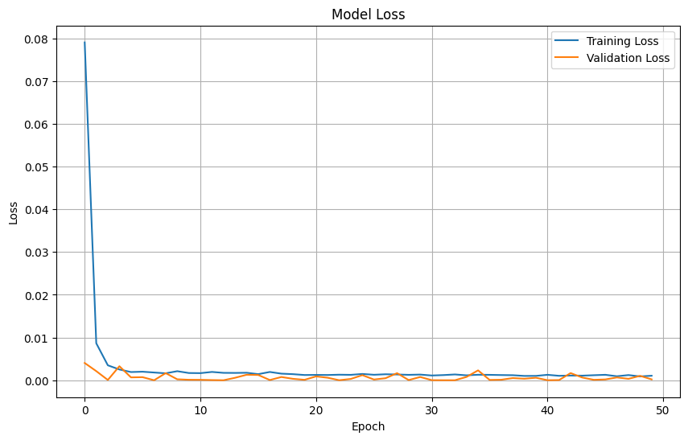

```python
import matplotlib.pyplot as plt

# Plot training & validation loss values
plt.figure(figsize=(10, 6))
plt.plot(history.history['loss'], label='Training Loss')
plt.plot(history.history['val_loss'], label='Validation Loss')
plt.title('Model Loss')
plt.xlabel('Epoch')
plt.ylabel('Loss')
plt.legend(loc='upper right')
plt.grid(True)
plt.show()
```

The model appears to have learned the patterns in the data well, as indicated by the low loss values and the close match between training and validation loss.

The fluctuations in the validation loss suggest that the model might still benefit from some regularization or hyperparameter tuning, but overall, the performance looks strong.

## **Implementing Hyperparameter Tuning:**

```python
from tensorflow.keras.optimizers import Adam
from tensorflow.keras.callbacks import EarlyStopping
from sklearn.model_selection import ParameterGrid

# Define the hyperparameters to tune
param_grid = {
    'learning_rate': [0.01, 0.001, 0.0001],
    'batch_size': [16, 32, 64],
    'lstm_units': [25, 50, 100],
    'dropout_rate': [0.2, 0.3, 0.5]
}

# Grid search for best hyperparameters
best_val_loss = float("inf")
best_params = None
best_model = None

for params in ParameterGrid(param_grid):
    print(f"Testing with params: {params}")

    # Build the model
    model = Sequential()
    model.add(LSTM(units=params['lstm_units'], return_sequences=True, input_shape=(X_train.shape[1], 1)))
    model.add(Dropout(params['dropout_rate']))
    model.add(LSTM(units=params['lstm_units'], return_sequences=False))
    model.add(Dropout(params['dropout_rate']))
    model.add(Dense(units=1))

    # Compile the model
    model.compile(optimizer=Adam(learning_rate=params['learning_rate']), loss='mean_squared_error')

    # Train the model
    history = model.fit(X_train, y_train, epochs=20, batch_size=params['batch_size'],
                        validation_data=(X_test, y_test), verbose=0,
                        callbacks=[EarlyStopping(monitor='val_loss', patience=5, restore_best_weights=True)])

    # Evaluate the model
    val_loss = min(history.history['val_loss'])
    print(f"Validation loss: {val_loss}")

    if val_loss < best_val_loss:
        best_val_loss = val_loss
        best_params = params
        best_model = model

print(f"\nBest Validation Loss: {best_val_loss}")
print(f"Best Hyperparameters: {best_params}")

# Save the best model
best_model.save('best_lstm_model.h5')
```

```
Testing with params: {'batch_size': 16, 'dropout_rate': 0.2, 'learning_rate': 0.01, 'lstm_units': 25}
Validation loss: 9.28648078115657e-05
Testing with params: {'batch_size': 16, 'dropout_rate': 0.2, 'learning_rate': 0.01, 'lstm_units': 50}
Validation loss: 9.291904279962182e-05
Testing with params: {'batch_size': 16, 'dropout_rate': 0.2, 'learning_rate': 0.01, 'lstm_units': 100}
Validation loss: 0.00017580042185727507
Testing with params: {'batch_size': 16, 'dropout_rate': 0.2, 'learning_rate': 0.001, 'lstm_units': 25}
Validation loss: 3.751536496565677e-05
Testing with params: {'batch_size': 16, 'dropout_rate': 0.2, 'learning_rate': 0.001, 'lstm_units': 50}
Validation loss: 3.1675599529989995e-06
Testing with params: {'batch_size': 16, 'dropout_rate': 0.2, 'learning_rate': 0.001, 'lstm_units': 100}
Validation loss: 1.3060166565992404e-06
Testing with params: {'batch_size': 16, 'dropout_rate': 0.2, 'learning_rate': 0.0001, 'lstm_units': 25}
Validation loss: 3.794610165641643e-05
Testing with params: {'batch_size': 16, 'dropout_rate': 0.2, 'learning_rate': 0.0001, 'lstm_units': 50}
Validation loss: 2.2174779587658122e-05
Testing with params: {'batch_size': 16, 'dropout_rate': 0.2, 'learning_rate': 0.0001, 'lstm_units': 100}
Validation loss: 1.823139245971106e-05
Testing with params: {'batch_size': 16, 'dropout_rate': 0.3, 'learning_rate': 0.01, 'lstm_units': 25}
Validation loss: 1.1329360631862073e-06
Testing with params: {'batch_size': 16, 'dropout_rate': 0.3, 'learning_rate': 0.01, 'lstm_units': 50}
Validation loss: 0.00014749054389540106
Testing with params: {'batch_size': 16, 'dropout_rate': 0.3, 'learning_rate': 0.01, 'lstm_units': 100}
Validation loss: 0.00023831910220906138
Testing with params: {'batch_size': 16, 'dropout_rate': 0.3, 'learning_rate': 0.001, 'lstm_units': 25}
Validation loss: 4.30041700383299e-06
Testing with params: {'batch_size': 16, 'dropout_rate': 0.3, 'learning_rate': 0.001, 'lstm_units': 50}
Validation loss: 4.3777990867965855e-06
Testing with params: {'batch_size': 16, 'dropout_rate': 0.3, 'learning_rate': 0.001, 'lstm_units': 100}
Validation loss: 0.00021579480380751193
Testing with params: {'batch_size': 16, 'dropout_rate': 0.3, 'learning_rate': 0.0001, 'lstm_units': 25}
Validation loss: 2.6241563318762928e-05
Testing with params: {'batch_size': 16, 'dropout_rate': 0.3, 'learning_rate': 0.0001, 'lstm_units': 50}
Validation loss: 2.4140568712027743e-05
Testing with params: {'batch_size': 16, 'dropout_rate': 0.3, 'learning_rate': 0.0001, 'lstm_units': 100}
Validation loss: 1.865455851657316e-05
Testing with params: {'batch_size': 16, 'dropout_rate': 0.5, 'learning_rate': 0.01, 'lstm_units': 25}
Validation loss: 3.609435952967033e-05
Testing with params: {'batch_size': 16, 'dropout_rate': 0.5, 'learning_rate': 0.01, 'lstm_units': 50}
Validation loss: 3.862925586872734e-05
```

[output cut: 106 more lines]

```
Testing with params: {'batch_size': 64, 'dropout_rate': 0.5, 'learning_rate': 0.01, 'lstm_units': 50}
Validation loss: 5.627003702102229e-05
Testing with params: {'batch_size': 64, 'dropout_rate': 0.5, 'learning_rate': 0.01, 'lstm_units': 100}
Validation loss: 0.00038425481761805713
Testing with params: {'batch_size': 64, 'dropout_rate': 0.5, 'learning_rate': 0.001, 'lstm_units': 25}
Validation loss: 7.099771755747497e-05
Testing with params: {'batch_size': 64, 'dropout_rate': 0.5, 'learning_rate': 0.001, 'lstm_units': 50}
Validation loss: 2.8497779567260295e-06
Testing with params: {'batch_size': 64, 'dropout_rate': 0.5, 'learning_rate': 0.001, 'lstm_units': 100}
Validation loss: 1.153844641521573e-05
Testing with params: {'batch_size': 64, 'dropout_rate': 0.5, 'learning_rate': 0.0001, 'lstm_units': 25}
Validation loss: 0.03943086415529251
Testing with params: {'batch_size': 64, 'dropout_rate': 0.5, 'learning_rate': 0.0001, 'lstm_units': 50}
Validation loss: 0.009183879010379314
Testing with params: {'batch_size': 64, 'dropout_rate': 0.5, 'learning_rate': 0.0001, 'lstm_units': 100}
```

```
WARNING:absl:You are saving your model as an HDF5 file via `model.save()` or `keras.saving.save_model(model)`. This file format is considered legacy. We recommend using instead the native Keras format, e.g. `model.save('my_model.keras')` or `keras.saving.save_model(model, 'my_model.keras')`.
```

```
Validation loss: 0.0008321321802213788

Best Validation Loss: 1.1329360631862073e-06
Best Hyperparameters: {'batch_size': 16, 'dropout_rate': 0.3, 'learning_rate': 0.01, 'lstm_units': 25}
```

### *Best Hyperparameters:*

Batch Size: 16

Dropout Rate: 0.3

LSTM Units: 25

These hyperparameters resulted in the best performance, suggesting that a smaller model (fewer LSTM units) with a moderate dropout rate and a smaller batch size works well for this particular dataset.

## **Visualize Predictions vs. Actuals**

```
6/6 ━━━━━━━━━━━━━━━━━━━━ 0s 44ms/step
```

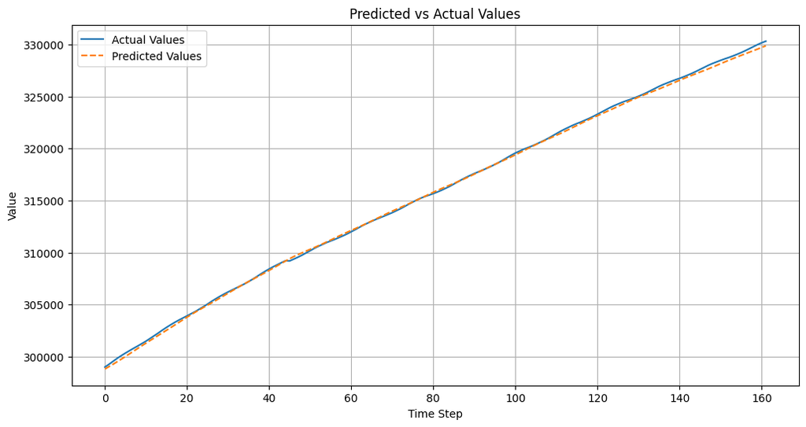

```python
import matplotlib.pyplot as plt

# Make predictions on the test set
y_pred = best_model.predict(X_test)

# Since we scaled the data earlier, we need to inverse transform the predictions and actuals
y_test_inverse = scaler.inverse_transform(y_test)
y_pred_inverse = scaler.inverse_transform(y_pred)

# Plot the results
plt.figure(figsize=(12, 6))
plt.plot(y_test_inverse, label='Actual Values')
plt.plot(y_pred_inverse, label='Predicted Values', linestyle='--')
plt.title('Predicted vs Actual Values')
plt.xlabel('Time Step')
plt.ylabel('Value')
plt.legend()
plt.grid(True)
plt.show()
```

### **Analysis of the Predicted vs. Actual Values Plot**

The plot shows the predicted values (orange dashed line) versus the actual values (blue solid line) for the test set:

**Close Match Between Predicted and Actual Values:**

The predicted values closely follow the actual values throughout the entire range. This indicates that the model is performing very well in capturing the underlying trend of the data.

**Consistency Across the Time Steps:**

The consistency of the predictions across all time steps suggests that the model has learned the trend effectively without significant overfitting or underfitting.

**Conclusion**

The model's predictions are highly accurate, as evidenced by the close alignment of the predicted and actual values in the plot. The tuning of hyperparameters appears to have been very successful, resulting in a model that generalizes well to unseen data.

## **Model Accuracy Evaluation**

```python
from sklearn.metrics import mean_absolute_error, mean_squared_error, r2_score
import numpy as np

# Calculate Mean Absolute Error (MAE)
mae = mean_absolute_error(y_test_inverse, y_pred_inverse)

# Calculate Root Mean Squared Error (RMSE)
rmse = np.sqrt(mean_squared_error(y_test_inverse, y_pred_inverse))

# Calculate R-squared (R²)
r2 = r2_score(y_test_inverse, y_pred_inverse)

# Print the results
print(f"Mean Absolute Error (MAE): {mae}")
print(f"Root Mean Squared Error (RMSE): {rmse}")
print(f"R-squared (R²): {r2}")
```

```
Mean Absolute Error (MAE): 154.47867592592561
Root Mean Squared Error (RMSE): 185.20275158068017
R-squared (R²): 0.9995690124723677
```

### **Model Accuracy Evaluation Analysis**

The RMSE is slightly higher than the MAE, which is expected since RMSE penalizes larger errors more than MAE. However, this value is still low relative to the scale of the data, indicating strong predictive accuracy.

The R² value is very close to 1, which means that the model explains nearly all the variance in the data. This is an excellent result, showing that the model is highly effective at capturing the underlying pattern in the dataset.

**Conclusion**

These metrics confirm that the model is performing exceptionally well:

Low MAE and RMSE values indicate minimal prediction error.

High R² value suggests the model is accurately capturing the relationship between the input features and the target variable.

# **Implementing Other Models and Comparing Models**

## **GRU Model**

```python
from tensorflow.keras.layers import GRU

# Define the GRU model
gru_model = Sequential()
gru_model.add(GRU(units=25, return_sequences=True, input_shape=(X_train.shape[1], 1)))
gru_model.add(Dropout(0.3))
gru_model.add(GRU(units=25, return_sequences=False))
gru_model.add(Dropout(0.3))
gru_model.add(Dense(units=1))

# Compile the model
gru_model.compile(optimizer=Adam(learning_rate=0.001), loss='mean_squared_error')

# Train the model
gru_history = gru_model.fit(X_train, y_train, epochs=50, batch_size=16, validation_data=(X_test, y_test), verbose=2)

# Evaluate GRU model
gru_y_pred = gru_model.predict(X_test)
gru_y_pred_inverse = scaler.inverse_transform(gru_y_pred)

gru_mae = mean_absolute_error(y_test_inverse, gru_y_pred_inverse)
gru_rmse = np.sqrt(mean_squared_error(y_test_inverse, gru_y_pred_inverse))
gru_r2 = r2_score(y_test_inverse, gru_y_pred_inverse)

print(f"GRU Model - MAE: {gru_mae}, RMSE: {gru_rmse}, R²: {gru_r2}")
```

```
41/41 - 2s - 54ms/step - loss: 0.0334 - val_loss: 0.0388
41/41 - 0s - 7ms/step - loss: 0.0093 - val_loss: 0.0011
41/41 - 0s - 6ms/step - loss: 0.0073 - val_loss: 0.0061
41/41 - 0s - 7ms/step - loss: 0.0071 - val_loss: 6.2643e-04
41/41 - 0s - 8ms/step - loss: 0.0059 - val_loss: 0.0049
41/41 - 0s - 6ms/step - loss: 0.0056 - val_loss: 5.7718e-04
41/41 - 0s - 6ms/step - loss: 0.0055 - val_loss: 9.4406e-05
41/41 - 0s - 8ms/step - loss: 0.0044 - val_loss: 7.1281e-04
41/41 - 0s - 6ms/step - loss: 0.0044 - val_loss: 0.0014
41/41 - 0s - 7ms/step - loss: 0.0043 - val_loss: 0.0020
41/41 - 0s - 8ms/step - loss: 0.0041 - val_loss: 0.0031
41/41 - 0s - 6ms/step - loss: 0.0037 - val_loss: 0.0010
41/41 - 0s - 8ms/step - loss: 0.0033 - val_loss: 0.0011
41/41 - 0s - 6ms/step - loss: 0.0042 - val_loss: 2.3293e-04
41/41 - 0s - 7ms/step - loss: 0.0031 - val_loss: 9.3921e-05
41/41 - 0s - 6ms/step - loss: 0.0031 - val_loss: 8.5070e-04
41/41 - 0s - 6ms/step - loss: 0.0030 - val_loss: 6.6748e-06
41/41 - 0s - 6ms/step - loss: 0.0034 - val_loss: 3.1627e-04
41/41 - 0s - 7ms/step - loss: 0.0027 - val_loss: 0.0016
41/41 - 0s - 7ms/step - loss: 0.0030 - val_loss: 0.0015
41/41 - 0s - 6ms/step - loss: 0.0029 - val_loss: 8.2703e-04
41/41 - 0s - 7ms/step - loss: 0.0025 - val_loss: 8.2417e-05
41/41 - 0s - 7ms/step - loss: 0.0026 - val_loss: 2.2231e-04
41/41 - 0s - 7ms/step - loss: 0.0024 - val_loss: 2.6685e-04
41/41 - 0s - 6ms/step - loss: 0.0026 - val_loss: 3.2663e-04
41/41 - 0s - 7ms/step - loss: 0.0024 - val_loss: 2.7687e-05
41/41 - 0s - 7ms/step - loss: 0.0024 - val_loss: 6.7915e-04
41/41 - 0s - 6ms/step - loss: 0.0022 - val_loss: 9.8564e-04
41/41 - 0s - 7ms/step - loss: 0.0024 - val_loss: 1.9175e-05
41/41 - 0s - 7ms/step - loss: 0.0021 - val_loss: 2.1310e-05
41/41 - 0s - 7ms/step - loss: 0.0021 - val_loss: 3.4561e-04
41/41 - 0s - 9ms/step - loss: 0.0020 - val_loss: 1.0531e-04
41/41 - 1s - 15ms/step - loss: 0.0020 - val_loss: 2.0806e-04
41/41 - 1s - 16ms/step - loss: 0.0017 - val_loss: 6.0925e-05
41/41 - 0s - 9ms/step - loss: 0.0019 - val_loss: 3.9717e-04
41/41 - 0s - 10ms/step - loss: 0.0018 - val_loss: 0.0033
41/41 - 0s - 11ms/step - loss: 0.0017 - val_loss: 0.0023
41/41 - 0s - 7ms/step - loss: 0.0018 - val_loss: 0.0021
41/41 - 0s - 7ms/step - loss: 0.0019 - val_loss: 0.0044
41/41 - 0s - 7ms/step - loss: 0.0018 - val_loss: 7.2963e-04
41/41 - 0s - 8ms/step - loss: 0.0016 - val_loss: 1.6818e-04
41/41 - 0s - 7ms/step - loss: 0.0016 - val_loss: 7.6732e-04
41/41 - 0s - 6ms/step - loss: 0.0014 - val_loss: 2.6031e-04
41/41 - 0s - 7ms/step - loss: 0.0016 - val_loss: 0.0010
41/41 - 0s - 7ms/step - loss: 0.0015 - val_loss: 0.0027
41/41 - 0s - 7ms/step - loss: 0.0015 - val_loss: 1.9814e-04
41/41 - 0s - 7ms/step - loss: 0.0015 - val_loss: 6.3126e-04
41/41 - 0s - 6ms/step - loss: 0.0016 - val_loss: 0.0016
41/41 - 0s - 6ms/step - loss: 0.0013 - val_loss: 5.3067e-05
41/41 - 0s - 8ms/step - loss: 0.0014 - val_loss: 0.0011
6/6 ━━━━━━━━━━━━━━━━━━━━ 0s 28ms/step
GRU Model - MAE: 5669.472313271604, RMSE: 5737.047066159026, R²: 0.5864322564510697
```

### **GRU Model Performance**

The RMSE is also much higher for the GRU model compared to the LSTM, indicating that the errors are more pronounced in this model.

## **Bidirectional LSTM Model**

```python
from tensorflow.keras.layers import Bidirectional

# Define the Bidirectional LSTM model
bi_lstm_model = Sequential()
bi_lstm_model.add(Bidirectional(LSTM(units=25, return_sequences=True), input_shape=(X_train.shape[1], 1)))
bi_lstm_model.add(Dropout(0.3))
bi_lstm_model.add(Bidirectional(LSTM(units=25, return_sequences=False)))
bi_lstm_model.add(Dropout(0.3))
bi_lstm_model.add(Dense(units=1))

# Compile the model
bi_lstm_model.compile(optimizer=Adam(learning_rate=0.001), loss='mean_squared_error')

# Train the model
bi_lstm_history = bi_lstm_model.fit(X_train, y_train, epochs=50, batch_size=16, validation_data=(X_test, y_test), verbose=2)

# Evaluate Bidirectional LSTM model
bi_lstm_y_pred = bi_lstm_model.predict(X_test)
bi_lstm_y_pred_inverse = scaler.inverse_transform(bi_lstm_y_pred)

bi_lstm_mae = mean_absolute_error(y_test_inverse, bi_lstm_y_pred_inverse)
bi_lstm_rmse = np.sqrt(mean_squared_error(y_test_inverse, bi_lstm_y_pred_inverse))
bi_lstm_r2 = r2_score(y_test_inverse, bi_lstm_y_pred_inverse)

print(f"Bidirectional LSTM Model - MAE: {bi_lstm_mae}, RMSE: {bi_lstm_rmse}, R²: {bi_lstm_r2}")
```

```
41/41 - 4s - 86ms/step - loss: 0.0194 - val_loss: 1.7782e-04
41/41 - 1s - 21ms/step - loss: 0.0043 - val_loss: 0.0024
41/41 - 1s - 15ms/step - loss: 0.0036 - val_loss: 0.0011
41/41 - 0s - 10ms/step - loss: 0.0031 - val_loss: 0.0021
41/41 - 0s - 10ms/step - loss: 0.0031 - val_loss: 4.4019e-04
41/41 - 1s - 13ms/step - loss: 0.0028 - val_loss: 2.2108e-04
41/41 - 1s - 14ms/step - loss: 0.0030 - val_loss: 0.0010
41/41 - 1s - 13ms/step - loss: 0.0028 - val_loss: 1.5078e-05
41/41 - 1s - 13ms/step - loss: 0.0024 - val_loss: 0.0029
41/41 - 1s - 16ms/step - loss: 0.0019 - val_loss: 7.7370e-05
41/41 - 1s - 13ms/step - loss: 0.0023 - val_loss: 5.0769e-04
41/41 - 1s - 12ms/step - loss: 0.0022 - val_loss: 2.4717e-04
41/41 - 1s - 15ms/step - loss: 0.0022 - val_loss: 1.2130e-05
41/41 - 1s - 15ms/step - loss: 0.0022 - val_loss: 0.0016
41/41 - 1s - 15ms/step - loss: 0.0021 - val_loss: 2.1769e-06
41/41 - 0s - 10ms/step - loss: 0.0018 - val_loss: 6.2099e-04
41/41 - 0s - 10ms/step - loss: 0.0018 - val_loss: 6.4707e-05
41/41 - 0s - 9ms/step - loss: 0.0021 - val_loss: 3.7550e-05
41/41 - 1s - 15ms/step - loss: 0.0017 - val_loss: 1.1096e-05
41/41 - 1s - 15ms/step - loss: 0.0021 - val_loss: 4.4888e-04
41/41 - 1s - 15ms/step - loss: 0.0014 - val_loss: 3.2815e-05
41/41 - 0s - 9ms/step - loss: 0.0015 - val_loss: 1.0837e-04
41/41 - 1s - 16ms/step - loss: 0.0014 - val_loss: 7.5838e-05
41/41 - 1s - 14ms/step - loss: 0.0014 - val_loss: 7.8548e-05
41/41 - 0s - 9ms/step - loss: 0.0017 - val_loss: 2.0982e-04
41/41 - 1s - 16ms/step - loss: 0.0014 - val_loss: 8.0226e-04
41/41 - 0s - 9ms/step - loss: 0.0013 - val_loss: 8.4744e-05
41/41 - 1s - 15ms/step - loss: 0.0016 - val_loss: 2.8336e-05
41/41 - 0s - 9ms/step - loss: 0.0014 - val_loss: 3.9863e-04
41/41 - 0s - 10ms/step - loss: 0.0014 - val_loss: 9.9902e-05
41/41 - 1s - 18ms/step - loss: 0.0015 - val_loss: 1.1479e-04
41/41 - 1s - 15ms/step - loss: 0.0015 - val_loss: 1.7120e-04
41/41 - 1s - 15ms/step - loss: 0.0013 - val_loss: 1.4232e-04
41/41 - 1s - 16ms/step - loss: 0.0013 - val_loss: 0.0026
41/41 - 1s - 15ms/step - loss: 0.0011 - val_loss: 1.0732e-05
41/41 - 0s - 10ms/step - loss: 0.0012 - val_loss: 3.8930e-04
41/41 - 1s - 15ms/step - loss: 0.0012 - val_loss: 4.4624e-04
41/41 - 0s - 10ms/step - loss: 0.0011 - val_loss: 4.1227e-04
41/41 - 1s - 14ms/step - loss: 0.0011 - val_loss: 5.5251e-04
41/41 - 0s - 9ms/step - loss: 0.0012 - val_loss: 5.9970e-04
41/41 - 0s - 9ms/step - loss: 9.6675e-04 - val_loss: 9.3354e-04
41/41 - 1s - 15ms/step - loss: 0.0012 - val_loss: 4.1140e-04
41/41 - 1s - 15ms/step - loss: 0.0012 - val_loss: 0.0035
41/41 - 1s - 16ms/step - loss: 0.0011 - val_loss: 2.6615e-04
41/41 - 0s - 10ms/step - loss: 9.2644e-04 - val_loss: 0.0011
41/41 - 0s - 9ms/step - loss: 8.6801e-04 - val_loss: 2.1038e-04
41/41 - 1s - 16ms/step - loss: 9.1343e-04 - val_loss: 2.6927e-04
41/41 - 0s - 9ms/step - loss: 8.6064e-04 - val_loss: 6.1047e-04
41/41 - 1s - 16ms/step - loss: 9.3849e-04 - val_loss: 2.9795e-05
41/41 - 1s - 15ms/step - loss: 8.8289e-04 - val_loss: 3.6217e-04
```

```
WARNING:tensorflow:5 out of the last 13 calls to <function TensorFlowTrainer.make_predict_function.<locals>.one_step_on_data_distributed at 0x7c6642e8d1b0> triggered tf.function retracing. Tracing is expensive and the excessive number of tracings could be due to (1) creating @tf.function repeatedly …
```

```
6/6 ━━━━━━━━━━━━━━━━━━━━ 1s 61ms/step
Bidirectional LSTM Model - MAE: 3299.264172839505, RMSE: 3311.3780995898874, R²: 0.862219620353053
```

### **Bidirectional LSTM Model Performance**

The RMSE is also lower than the GRU model but higher than the LSTM model. This suggests that the Bidirectional LSTM model performs better than GRU but still has larger errors compared to the LSTM.

## **Comparison and Conclusion**

### **LSTM Model:**

The standard LSTM model still performs the best among the models tested, with the lowest MAE and RMSE, and the highest R², indicating it captures the patterns in the data most effectively.

### **Bidirectional LSTM Model:**

While it performs better than the GRU model, it doesn't match the accuracy of the LSTM model. The bidirectional nature might be adding complexity without a proportional gain in performance for this dataset.

### **GRU Model:**

The GRU model performs the worst among the three, with the highest MAE and RMSE and the lowest R².

## **Visualizing Model Metrics**

```python
import matplotlib.pyplot as plt

# Function to plot loss curves
def plot_loss_curves(history, title="Model Loss"):
    plt.figure(figsize=(10, 6))
    plt.plot(history.history['loss'], label='Training Loss')
    plt.plot(history.history['val_loss'], label='Validation Loss')
    plt.title(title)
    plt.xlabel('Epoch')
    plt.ylabel('Loss')
    plt.legend(loc='upper right')
    plt.grid(True)
    plt.show()

# Function to plot residuals
def plot_residuals(y_true, y_pred, title="Residuals Plot"):
    residuals = y_true - y_pred
    plt.figure(figsize=(10, 6))
    plt.scatter(y_pred, residuals)
    plt.title(title)
    plt.xlabel('Predicted Values')
    plt.ylabel('Residuals')
    plt.axhline(0, color='red', linestyle='--')
    plt.grid(True)
    plt.show()

# Function to plot predictions vs actuals
def plot_predictions_vs_actuals(y_true, y_pred, title="Predictions vs Actuals"):
    plt.figure(figsize=(10, 6))
    plt.scatter(y_true, y_pred, alpha=0.5)
    plt.title(title)
    plt.xlabel('Actual Values')
    plt.ylabel('Predicted Values')
    plt.plot([y_true.min(), y_true.max()], [y_true.min(), y_true.max()], 'r--')
    plt.grid(True)
    plt.show()
```

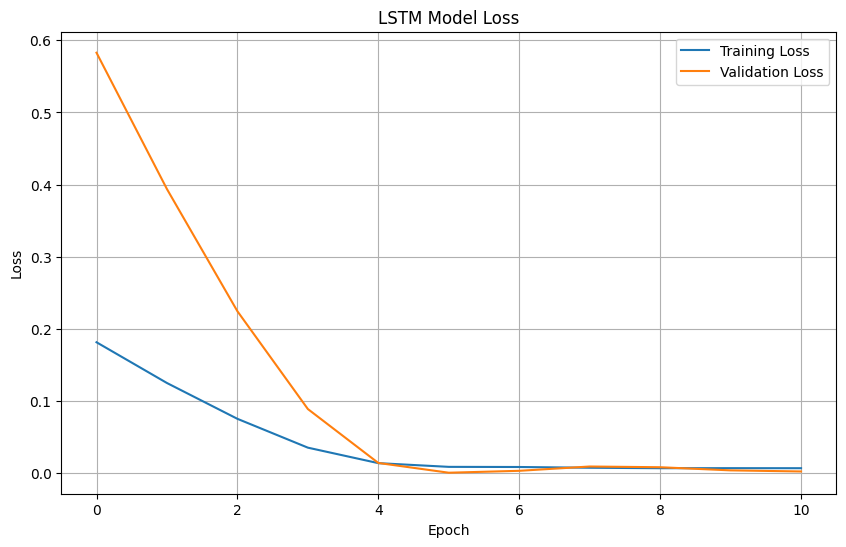

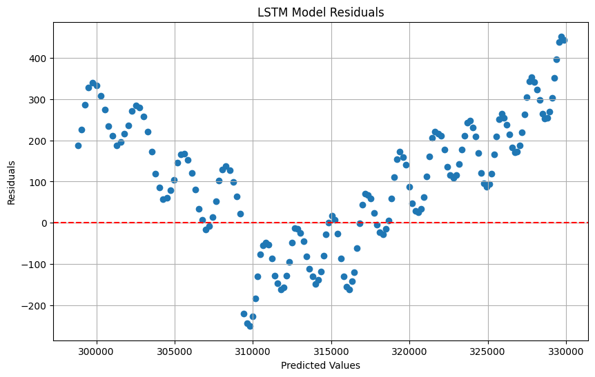

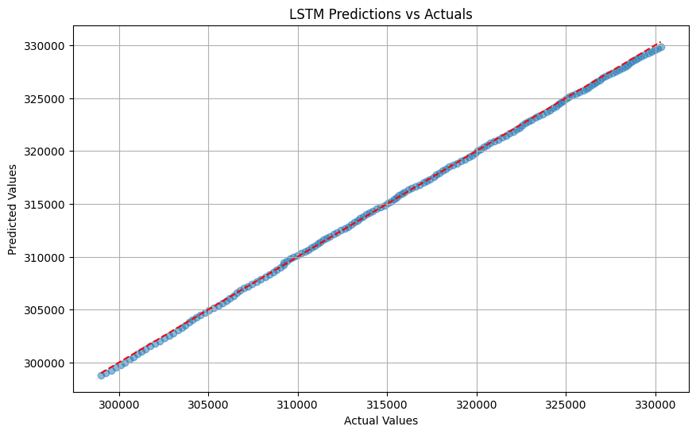

```python
# Plotting for LSTM model
plot_loss_curves(history, title="LSTM Model Loss")
plot_residuals(y_test_inverse, y_pred_inverse, title="LSTM Model Residuals")
plot_predictions_vs_actuals(y_test_inverse, y_pred_inverse, title="LSTM Predictions vs Actuals")
```

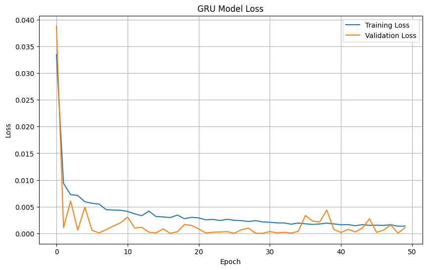

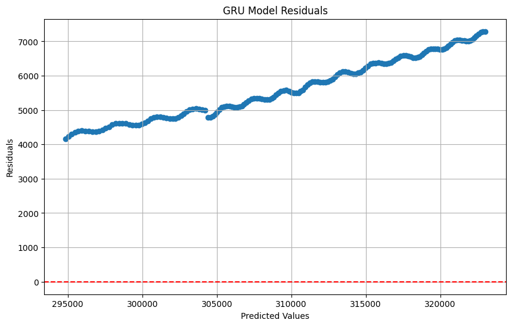

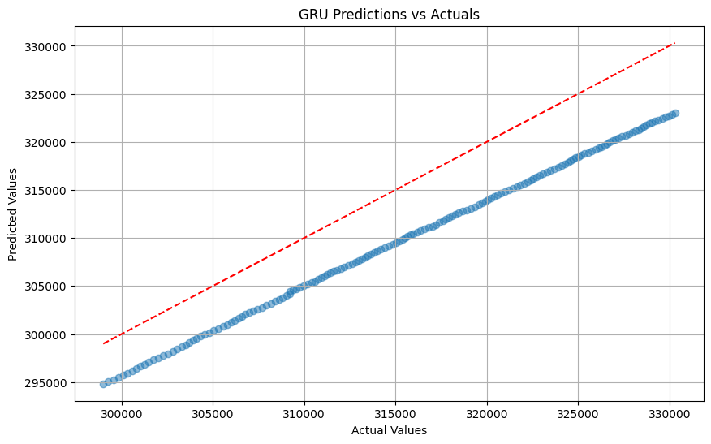

```python
# Plotting for GRU model
plot_loss_curves(gru_history, title="GRU Model Loss")
plot_residuals(y_test_inverse, gru_y_pred_inverse, title="GRU Model Residuals")
plot_predictions_vs_actuals(y_test_inverse, gru_y_pred_inverse, title="GRU Predictions vs Actuals")
```

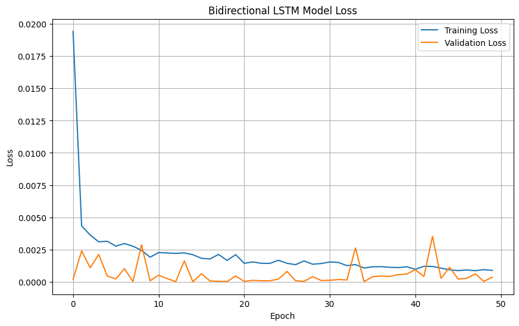

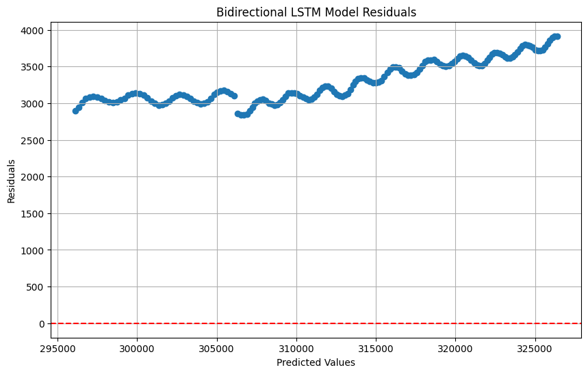

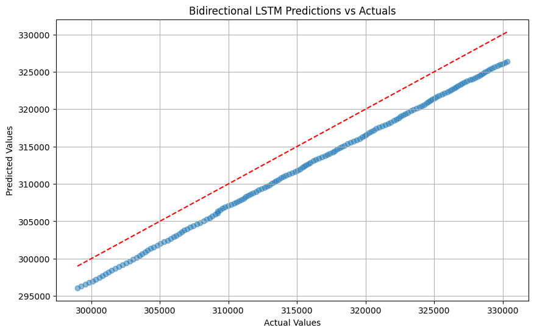

```python
# Plotting for Bidirectional LSTM model
plot_loss_curves(bi_lstm_history, title="Bidirectional LSTM Model Loss")
plot_residuals(y_test_inverse, bi_lstm_y_pred_inverse, title="Bidirectional LSTM Model Residuals")
plot_predictions_vs_actuals(y_test_inverse, bi_lstm_y_pred_inverse, title="Bidirectional LSTM Predictions vs Actuals")
```

### **Analysis of Model Metrics and Visualizations**

#### **1. LSTM Model:**

Predictions vs. Actuals: The predictions closely align with the actual values, showing the model's strong predictive power.

#### **2. GRU Model:**

Loss Curves: The validation loss shows some fluctuations, indicating that the model might not have stabilized as well as the LSTM model.

Residuals Plot: There is a clear pattern in the residuals, with increasing error as the predicted value increases, which suggests the model struggles more with larger values.

Predictions vs. Actuals: The predictions deviate more from the actual values compared to the LSTM model, confirming the weaker performance.

#### **3. Bidirectional LSTM Model:**

Loss Curves: Similar to the GRU, the Bidirectional LSTM shows some instability in validation loss, although it performs better than the GRU model.

Residuals Plot: Like the GRU, this model also shows a pattern in the residuals, with errors increasing as predicted values increase.

Predictions vs. Actuals: While better than the GRU, this model still shows less alignment between predicted and actual values compared to the LSTM.

### **Limitations:**

The model’s performance is highly dependent on the quality and consistency of the input data. Significant changes in population trends that were not captured in the historical data may impact the model’s accuracy.

### **Key Takeaways:**

- Further tuning and testing on more diverse datasets could enhance the model’s robustness.
- Exploring more complex architectures like hybrid models combining LSTM with other techniques (e.g., attention mechanisms) could provide further improvements.

## **Conclusion**

LSTM Model: The LSTM remains the best model with the most stable training, low residuals, and close alignment between predictions and actual values.

GRU and Bidirectional LSTM Models: These models show less stability, larger errors, and patterns in the residuals, indicating they are not as well-suited for this dataset.